# Composición de trabajo con contrato en Chile: Duración, salario, sexo y edad

Sociología UAH / Prof. Valentina Andrade /Ayudantes: Nicolas Godoy & Dafne Jaime

Fátima Lusangi

22-11-2021

## Abstract:

## Introducción:

## Análisis:

#### Composición y distribución de personas ocupadas que tienen contrato escrito:

**Gráfico 1:** composición sexo y edad ocupados con contrato escrito.

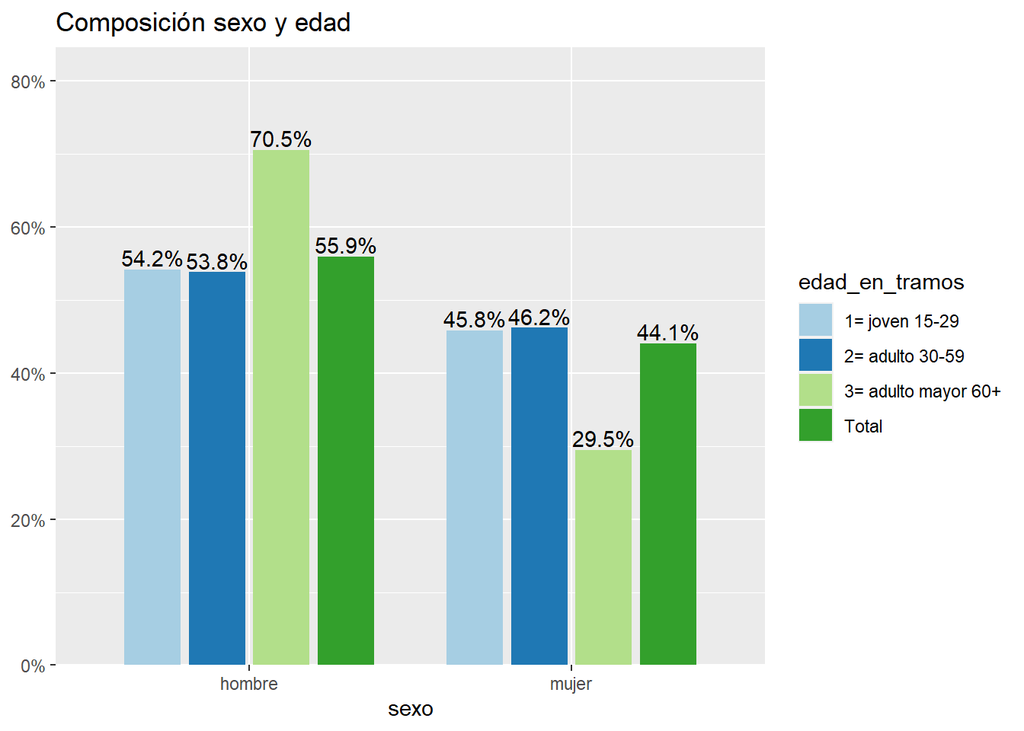

En el gráfico 1 vemos la composición de sexo y edad en tramos de la muestra de la ESI 2020 de las personas que tienen un contrato escrito, vemos que en su mayoría son hombres, 55,9%, versus el 44,1% de mujeres.

**Gráfico 2:** Edad en tramos

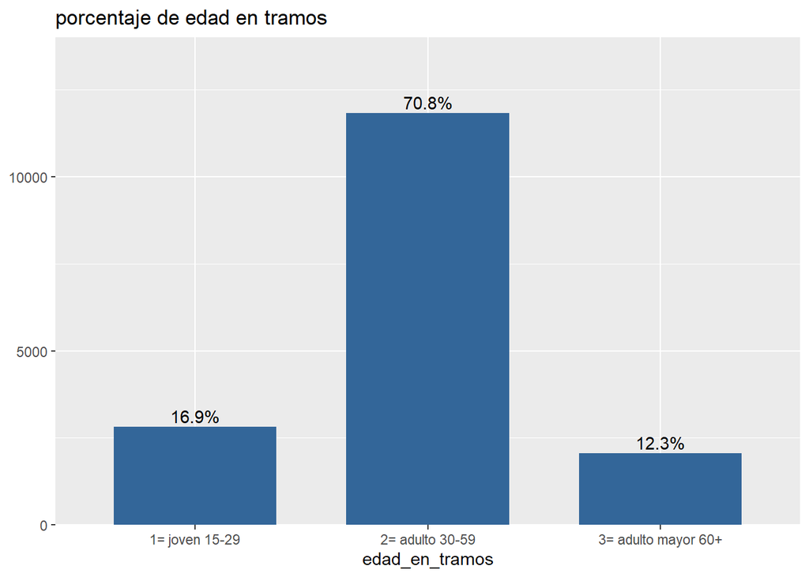

En el gráfico 2 podemos ver que el 16,9% son jovenes de 15 a 29 años, de los cuales respecto al gráfico 1 54,2% son hombres y 45,8% mujeres. el 70,8% son adultos de 30 a 59 años, de los cuales respecto al gráfico 1 53,8% son hombres y 46,2% mujeres. el 12,3% son adultos mayores de 60 y más años, de los cuales respecto al gráfico 1 70,5% son hombres y 29,5% mujeres.

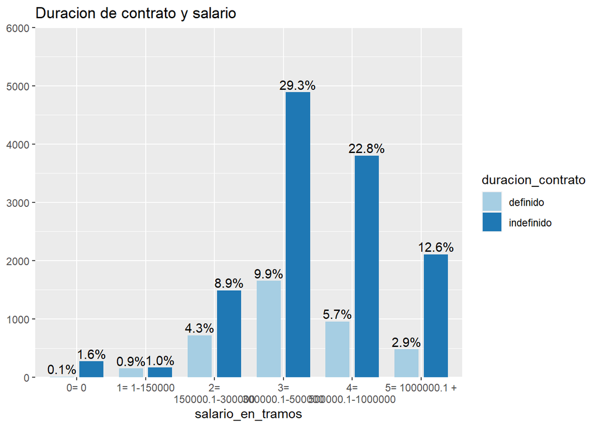

En el gráfico 3 encontramos la duración del contrato y los salarios en tramos que reciben, destaca que la mayoría de las personas tiene un salario de entre $300.000,1 y $500.000 y son personas con contratos indefinidos, que también concentran la mayor parte de los contratos escritos.

Respecto de la mediana poblacional el 50% de las personas tiene un salario neto de hasta $496.653, lo cual parece un mejor estimador que el promedio poblacional que es de $704.594,2.

#### División sexual de salarios de personas con contrato escrito:

**Tabla 1**: Salario promedio por sexo a nivel poblacional de personas con contrato escrito

| sexo | salario_promedio_sexo | salario_promedio_sexo_se |
| --- | --- | --- |
| hombre | 760325.4 | 12736.65 |
| mujer | 625320.1 | 10041.01 |

Podemos observar en la tabla que existe una brecha de género salarial en personas con contrato escrito ya que en promedio las mujeres tienen un salario neto de $625.320,1 mientras que en promedio los hombres tienen un salario neto de $760.325,4.